# TP7

## Exercice 1

```r
if (!requireNamespace("data.table", quietly = TRUE)) {
  install.packages("data.table")  # Installe le package si nécessaire
}
library(data.table)  # Charge le package

mu <- 2; sigma <- 1; N <- 1000; n=50
dataG <- matrix(rnorm(N*n,mu,sigma),ncol=n,nrow=N)
```

```r
moys <- rowMeans(dataG)
```

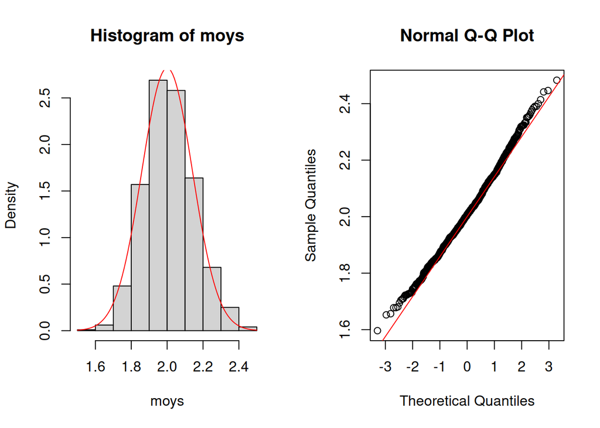

```r
par(mfrow=c(1,2))
hist(moys,probability=TRUE)
curve(dnorm(x,mu,sigma/sqrt(n)),add=T,col="red")
qqnorm(moys)
abline(mu,sigma/sqrt(n),col="red")
```

```r
mu0 <- 2
test1 <- sum(moys>mu0)/N
test2 <- sum(moys>mu0+2/sqrt(n))/N
test3 <- sum(moys>mu0+3/sqrt(n))/N
cat("Risque de première espèce du test1:",test1," test2:",test2," test3:",test3)
```

```
## Risque de première espèce du test1: 0.519  test2: 0.036  test3: 0.003
```

Pour le test 1, la distribution ayant $\mu_0$ comme axe de symétrie, il y a en effet une chance sur deux de refuser $H_0$ alors que $H_0$ est vrai.

Pour le test 2 , on est à 2 $\sigma$ (cf. TP3 Exercice 1 Q3), donc la probabilité de refuser $H_0$ à tort est 1-pnorm(2)=0.023.

De même pour le test 3 on doit obtenir un risque de première espèce de 1-pnorm(3)=0.001.

```r
Calpha <- qnorm(1-0.05,mu0,sigma/sqrt(n)) # ou mu0+qnorm(1-0.05)*sigma/sqrt(n)
cat("Calpha = ",Calpha)
```

```
## Calpha =  2.232617
```

```r
test <- sum(moys>Calpha)/N
cat("Risque de première espèce du test",test) # doit être proche de 0.05
```

```
## Risque de première espèce du test 0.067
```

6. Statistique de test $T=\frac{\bar{x}-\mu}{\sigma/\sqrt{n}}>u_{1-\alpha}$:

```r
tcalc <- (moys-mu0)/(sigma/sqrt(n))
sum(tcalc>qnorm(1-0.05))/N
```

```
## [1] 0.067
```

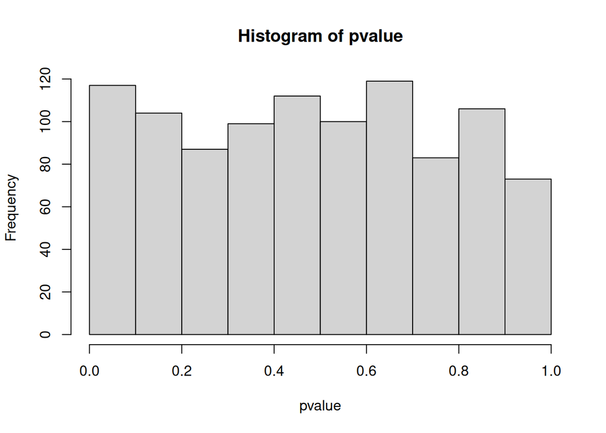

```r
pvalue <- 1-pnorm(moys,mu0,sigma/sqrt(n)) # ou 1-pnorm(tcalc)
hist(pvalue)
```

Si $H_0$ est vrai, la p-valeur suit une loi uniforme. Vous pouvez donc voir que la p-valeur ne peut rien vous dire sur la probabilité que H0 soit vraie. Elle ne peut que vous permettre d’évaluer le risque de refuser H0 à tort.

```r
sds <- apply(dataG,1,sd) # calcul des écarts types
sum(moys>mu0+qt(1-0.05,n-1)*sds/sqrt(n))/N # doit être proche de  0.05
```

```
## [1] 0.066
```

## Exercice 2

```r
data <- read.table("~/Personal/University/Semestre_4/401_STA/TP/Donnees/apnee.csv",header=TRUE, sep = ",")
```

```r
poidsH <- data[data$sexe==0,"poids"]
```

```r
moyest <- mean(poidsH)
varest <- var(poidsH)
```

```r
mu0 <- 87
n <- length(poidsH)
alpha <- seq(0.01,0.1,0.01)
kable(data.table(alpha=alpha,test=moyest>mu0+qt(1-alpha,n-1)*(sd(poidsH)/sqrt(n))))
```

| alpha | test |
| --- | --- |
| 0.01 | FALSE |
| 0.02 | FALSE |
| 0.03 | FALSE |
| 0.04 | FALSE |
| 0.05 | TRUE |
| 0.06 | TRUE |
| 0.07 | TRUE |
| 0.08 | TRUE |
| 0.09 | TRUE |
| 0.10 | TRUE |

Le changement de décision est pour $0.04<\alpha<0.05$.

```r
tcalc <- (moyest-mu0)/(sd(poidsH)/sqrt(n))
(pvalue <- 1-pt(tcalc,n-1))
```

```
## [1] 0.04523101
```

```r
t.test(poidsH,mu=87,alternative="greater")
```

```
##
##  One Sample t-test
##
## data:  poidsH
## t = 1.7154, df = 74, p-value = 0.04523
## alternative hypothesis: true mean is greater than 87
## 95 percent confidence interval:
##  87.10925      Inf
## sample estimates:
## mean of x
##  90.77333
```

On retrouve bien les valeurs de la statistique de test tcalc et de la p-valeur calculée précédement.